# Assignment_9

Emily Naylor

10/27/2020

# What matters for graduate school admission?

## Introduction

When students finish their undergraduate degree, many decide that they want to further their education by going to graduate school. But what factors are important to getting accepted into graduate school? There are a few parts of the application that applicants submit for acceptance to graduate schools. This assignment will look at GRE score, GPA, and the rank of the undergraduate institution.

The data used was a set of 400 undergraduate students who applied to graduate programs. The data includes whether or not the student was accepted, the rank of their undergraduate institution where rank 1 is considered “top tier”, their GRE score, and GPA

```r
# Packages
library(modelr)
library(broom)
library(tidyverse)
library(MASS)
library(car)
library(dplyr)
library(patchwork)
library(EnvStats)
library(GGally)
```

```r
#loaded in data
df <- read.csv("../../Data/GradSchool_Admissions.csv")
#changed whether they were admitted or not as a true or false.
df$admit <- as.logical(df$admit)
#change rank as a factor
df$rank <- as.factor(df$rank)
```

**TABLE 1.1** Summary of the data. Out of the 400 applicants, 127 of them were accepted into graduate school. 61 of the students came from a rank 1 undergraduate school, 151 came from a rank 2 school, 121 came from a rank 3, and there were 67 from a rank 4 undergraduate school. The average GRE score was 587.7 and the average GPA was 3.39.

```r
summary(df)
```

```
##    admit              gre             gpa        rank
##  Mode :logical   Min.   :220.0   Min.   :2.260   1: 61
##  FALSE:273       1st Qu.:520.0   1st Qu.:3.130   2:151
##  TRUE :127       Median :580.0   Median :3.395   3:121
##                  Mean   :587.7   Mean   :3.390   4: 67
##                  3rd Qu.:660.0   3rd Qu.:3.670
##                  Max.   :800.0   Max.   :4.000
```

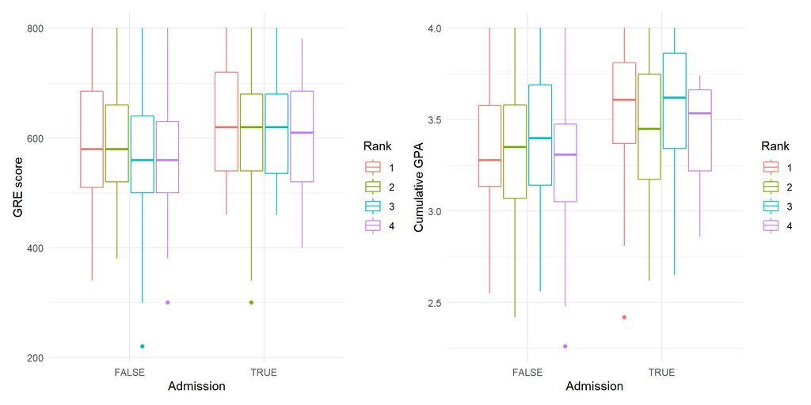

```r
p1 <- ggplot(df,aes(color=rank))+
  geom_boxplot(aes(y=gre, x=as.factor(admit)))+
  labs(x="Admission", y="GRE score", color="Rank")+
  theme_minimal()
p2 <- ggplot(df,aes(color=rank))+
  geom_boxplot(aes(y=gpa, x=as.factor(admit)))+
  labs(x="Admission", y="Cumulative GPA", color="Rank")+
  theme_minimal()
p1+p2
```

**FIGURE 1.1** Box-plot of admission by GRE scores and GPA where they were accepted if true and not accepted if false. The scores are colored by rank where 1 is a “top tier” undergraduate school. Most of the students who were accepted had an average GRE score of over 600 and an average GPA of around 3.5.

## Methods and Models

**TABLE 2.1** Table looking at the possibility of potential outliers within the GRE score data that can be seen in figure 1.1. The outliers were tested for using the Rosner test. There were not outliers found within the data.

```r
gretest <- rosnerTest(df$gre,
  k = 3)
```

```r
gretest$all.stats
```

```
##   i   Mean.i     SD.i Value Obs.Num    R.i+1 lambda.i+1 Outlier
## 1 0 587.7000 115.5165   220     305 3.183094   3.803268   FALSE
## 2 1 588.6216 114.1799   300      72 2.527780   3.802588   FALSE
## 3 2 589.3467 113.3998   300     180 2.551562   3.801905   FALSE
```

**TABLE 2.2** Table looking at the possibility of potential outliers within the GPA data that can be seen in figure 1.1. The outliers were tested for using the Rosner test. There were not outliers found within the data.

```r
gpatest <- rosnerTest(df$gpa,
  k = 3)
```

```r
gpatest$all.stats
```

```
##   i   Mean.i      SD.i Value Obs.Num    R.i+1 lambda.i+1 Outlier
## 1 0 3.389900 0.3805668  2.26     290 2.968993   3.803268   FALSE
## 2 1 3.392732 0.3768013  2.42      41 2.581551   3.802588   FALSE
## 3 2 3.395176 0.3740955  2.42     373 2.606756   3.801905   FALSE
```

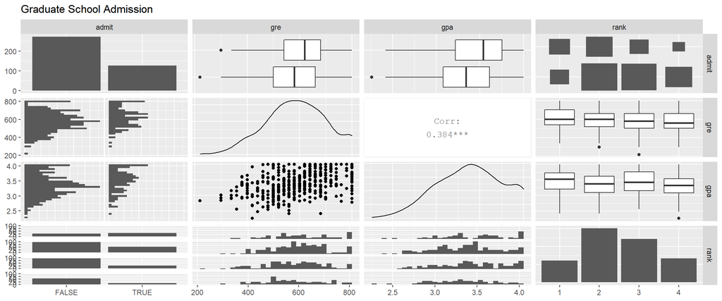

```r
ggpairs(data = df, columns = 1:4, title = "Graduate School Admission")
```

**FIGURE 2.1** A series of plots showing the different possible correlations of the data. There is a possible positive correlation between admission with GRE score, GPA, and rank. There also is a positive correlation between GPA and GRE score.

The correlation between rank and admission was much less clear so a chi-square test was used to verify that there is a correlation between admission into graduate school and the rank of the students undergraduate school.

```r
chisq.test(table(df$admit, df$rank), correct = FALSE)
summary(table(df$admit, df$rank))
qchisq(0.95, 4-1)
```

[output not shown]

### MODEL 1

Created a model that has admission as a function of rank, GRE scores, and GPA using a generalized linear model, while also taking into account the relationship between GRE score and GPA.

```r
mod_all <- glm(data=df, admit ~ gre*gpa*rank, family = "binomial")
summary(mod_all)
```

[output not shown]

```r
mod1 <- stepAIC(mod_all)
```

```r
summary(mod1)
```

```
##
## Call:
## glm(formula = admit ~ gre + gpa + rank + gre:gpa, family = "binomial",
##     data = df)
##
## Deviance Residuals:
##     Min       1Q   Median       3Q      Max
## -1.4815  -0.8772  -0.6357   1.1243   2.2612
##
## Coefficients:
##               Estimate Std. Error z value Pr(>|z|)
## (Intercept) -13.608810   6.071148  -2.242 0.024990 *
## gre           0.018344   0.009968   1.840 0.065722 .
## gpa           3.652170   1.788448   2.042 0.041143 *
## rank2        -0.721697   0.319150  -2.261 0.023740 *
## rank3        -1.343466   0.346383  -3.879 0.000105 ***
## rank4        -1.606298   0.420991  -3.816 0.000136 ***
## gre:gpa      -0.004719   0.002898  -1.629 0.103418
## ---
## Signif. codes:  0 '***' 0.001 '**' 0.01 '*' 0.05 '.' 0.1 ' ' 1
##
## (Dispersion parameter for binomial family taken to be 1)
##
##     Null deviance: 499.98  on 399  degrees of freedom
## Residual deviance: 455.77  on 393  degrees of freedom
## AIC: 469.77
##
## Number of Fisher Scoring iterations: 4
```

### MODEL 2

Created a model that has admission as a function of rank, GRE scores, and GPA using a generalized linear model, while not taking into account the relationship between GRE score and GPA.

```r
mod2 <- glm(formula = admit ~ gre + gpa + rank, family = "binomial",
    data = df)
```

**TABLE 3.2** Summary of the generalized linear model. There was a significant p-value for admission being a function of the GRE score, GPA, and rank with rank 3 and rank 4 having a particularly low p-value.

```r
summary(mod2)
```

```
##
## Call:
## glm(formula = admit ~ gre + gpa + rank, family = "binomial",
##     data = df)
##
## Deviance Residuals:
##     Min       1Q   Median       3Q      Max
## -1.6268  -0.8662  -0.6388   1.1490   2.0790
##
## Coefficients:
##              Estimate Std. Error z value Pr(>|z|)
## (Intercept) -3.989979   1.139951  -3.500 0.000465 ***
## gre          0.002264   0.001094   2.070 0.038465 *
## gpa          0.804038   0.331819   2.423 0.015388 *
## rank2       -0.675443   0.316490  -2.134 0.032829 *
## rank3       -1.340204   0.345306  -3.881 0.000104 ***
## rank4       -1.551464   0.417832  -3.713 0.000205 ***
## ---
## Signif. codes:  0 '***' 0.001 '**' 0.01 '*' 0.05 '.' 0.1 ' ' 1
##
## (Dispersion parameter for binomial family taken to be 1)
##
##     Null deviance: 499.98  on 399  degrees of freedom
## Residual deviance: 458.52  on 394  degrees of freedom
## AIC: 470.52
##
## Number of Fisher Scoring iterations: 4
```

The best model was determined using the mean squared residuals. The mean squared residual for model 1 is the top value and model 2 is the value at the bottom.

```r
mean(mod1$residuals^2)
```

```
## [1] 5.859484
```

```r
mean(mod2$residuals^2)
```

```
## [1] 5.419835
```

The second model had the lowest mean residual so it was used as the model for predicting a student’s admission or not.

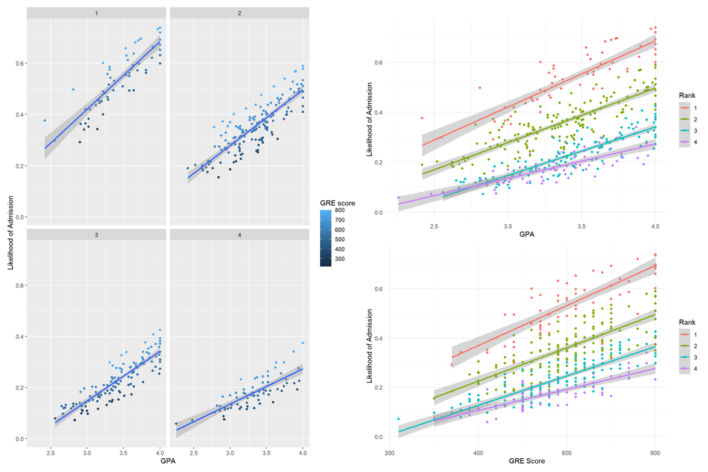

```r
p3 <- add_predictions(df,mod2,type = "response") %>%
  ggplot(aes(x=gpa,y=pred, color=gre))+
  geom_point()+
  geom_smooth(method = "lm")+
  labs(x="GPA", y="Likelihood of Admission", color="GRE score")+
  facet_wrap(~rank)
p4 <- add_predictions(df,mod2,type = "response") %>%
  ggplot(aes(x=gpa,y=pred, color=rank))+
  geom_point()+
  geom_smooth(method = "lm")+
  labs(x="GPA", y="Likelihood of Admission", color="Rank")+
  theme_minimal()
p5 <- add_predictions(df,mod2,type = "response") %>%
  ggplot(aes(x=gre,y=pred, color=rank))+
  geom_point()+
  geom_smooth(method = "lm")+
  labs(x="GRE Score", y="Likelihood of Admission", color="Rank")+
  theme_minimal()
p3+p4/p5
```

**Figure 3.1** Plots showing the likelihood of admission to graduate school based upon an undergraduate’s school rank, GRE score, and GPA.

## Conclusion

Based on the models above, an undergraduate student’s GPA and GRE scores do seem to have a significant effect on their chance of getting in to graduate school. Notably, if a student applies from an undergraduate school with a ranking of 1 or 2, they will have better odds of graduate school acceptance than a student applying from a rank 3 or 4 school.